# ECLT app notes

CL

2024-07-10

## https://drclongstaff.github.io/ECLT_CL/

### A Shiny app for clot lysis and Euglobulin Clot Lysis Time (ECLT) curves

There are a number of apps available at https://drclongstaff.github.io/shiny-clots/ which have varying degrees of complexity for different applications such as analysis of clotting and or lysis curves etc.

This app is simple in design for 2 reasons:

- The intention is to analyse noisy ECLT curves, so the time to 50% lysis is identified as the nearest time point without interpolation. There is also an option to remove some curves that are not going to provide usable results but may crash the analysis.
- The app is written using the Shinylive framework and is not run from a server. This means that R and all the necessary packages are downloaded to the user’s browser, and hence simple code will run more quickly and efficiently.

### Raw data

The app consists of one page, with widgets to load and manipulate data, and to generate results.

User data are loaded as a csv file (the only format available in this particular app). As usual, data should be presented as a spreadsheet of one column of Time plus any number of columns of Absorbance data.

Initially the loaded data are shown by default as ‘Raw’ as plots and in table form as Time versus Absorbance (or whatever the user has provided) for all wells. Examination of the plots may indicate some wells contain no useful data that can be removed by typing the well numbers as shown below.

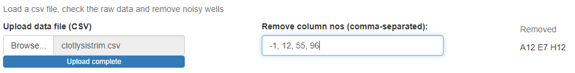

The plots are arranged by changing the ‘Plot number of rows’ dialog box. The default is 8 for a 96 well plate.

### Analysed data

Selecting the analysed radio button brings further options into play.

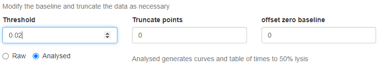

*Threshold*

The Threshold value is the lower limit of absorbance for useful data. If all data are below this value (for example an empty or removed well) the answer returned for clot lysis time will be NA.

*Truncated points*

The number entered in this dialog box specifies the number of points removed from the end of all the data. Adjusting this value is useful if the data readings go on for too long or become noisy at the end of the clot lysis run.

*Offset zero baseline*

The entry in this dialog box is an absorbance value to adjust the baseline. By default all curves are normalised at zero to the lowest absorbance reading recorded. This baseline can be moved up or down for all curves by adjusting the value entered in this box.

### Graphical Output and Results

When data are loaded, plots are shown of raw data and data are presented in table form, as provided. Plots are scaled from zero to the overall maximum absorbance x 1.2

When the ‘Analysed’ radio button is selected the plots change to include dashed lines showing the time to 50% lysis and the baseline. The curves are coloured to indicate the timecourse to 50% lysis (or maximum if this point is not reached) in red. The timecourse after this point is coloured blue.

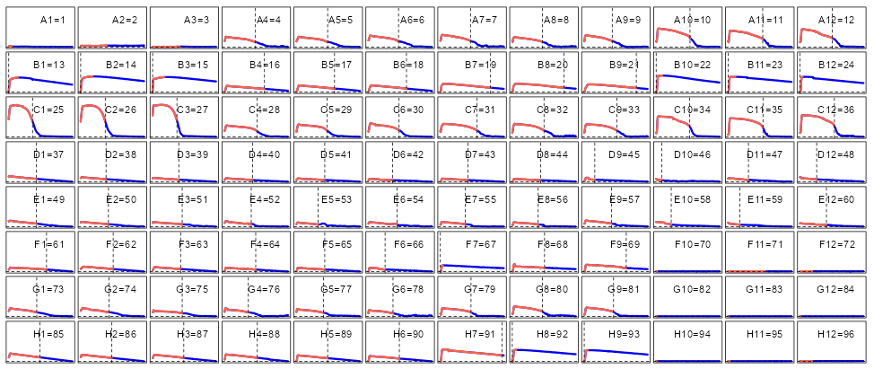

The results table is shown below the plots. As can be seen in this example, times to 50% lysis are provided where available. Where absorbance values are below the the *Threshold* an NA is returned; and where 50% lysis is not achieved, a value of zero is returned.

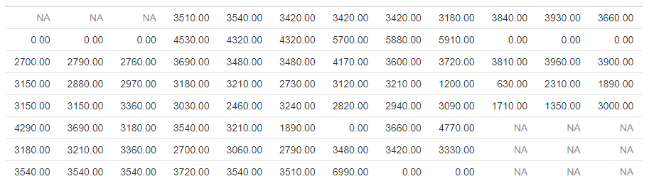

For more apps see https://github.com/drclongstaff/shiny-clots

Questions of issues contact: drclongtaff@gmail.com